# Classification with population size and euclidean distance constraints

Experiments on Val-de-Marne

Author

Claude Grasland

## Objective

The aim of this note is to experiment methods of classification with population and euclidean distance constraint. They don not fulfill necessarily the contiguity constraint but offers some interesting results for discussion

## The 11 electoral circonscriptions

We remind the spatial organisation of the 11 electoral circonscriptions of the Val de Marne that has been described in the previous analysis

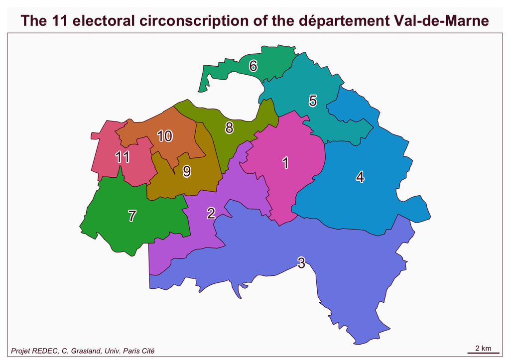

## Exepected size of circonscription

Using the number of *inscrits* as criterium, we can see that the average size of circonscription should be :

```
[1] "Number of inscrits :  787146"
```

```
[1] "Number of circonscriptions : 11"
```

```
[1] "Ideal size :  71559"
```

```
[1] "Margin with + or - 10% : [ 64403 ; 78715 ]"
```

## Communes as building blocks : not impossible but …

Can we use the commune as building blocks ?

```
# A tibble: 6 × 2
  com_name              inscrits
  <chr>                    <dbl>
1 Saint-Maur-des-Fossés    50971
2 Vitry-sur-Seine          46694
3 Créteil                  43833
4 Champigny-sur-Marne      43614
5 Fontenay-sous-Bois       36578
6 Maisons-Alfort           33756
```

At first glance, it seems to be possible because none of the commune has a number of inscrits higher than the upper limit of size. But it will be practically difficult because it is not necessary possible to complete a big commune by a smaller one in every case. Just look at the map.

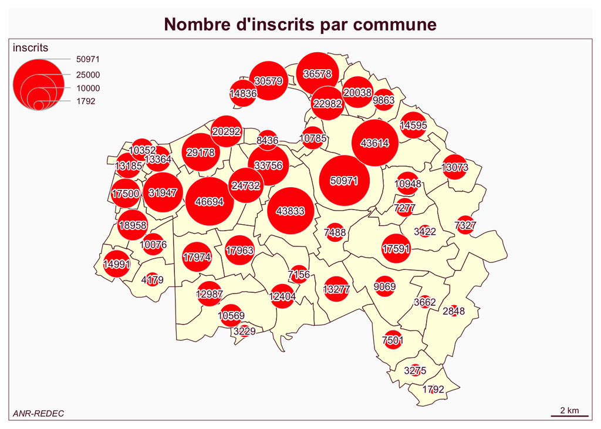

## IRIS as building blocks

The IRIS which are part of communes used by the INSEE for census are certainly a better choice. If we except some specific IRIS associated to industrial area, forest, etc, the divisions are generally characterized by relative proximity in terms of population and number of households. They are also relatively homogeneous in terms of housing and social characteristics. Last but not least, they are associated to a very large number of informations and can be, somehow, intersected with electoral data.

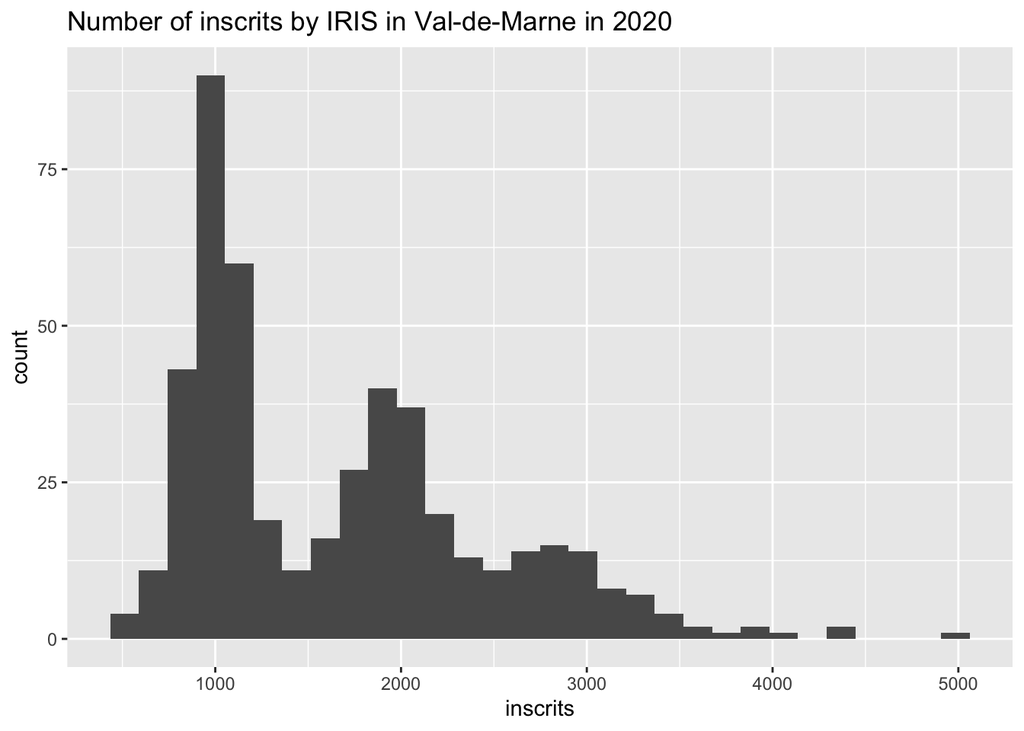

The fact that the distribution presented here is bimodal can be explained by the fact that the number of inscrits has been derived from the intersection between vote office and IRIS and is not perfectly accurate. But we could use more exact data by using information from census based on age and nationality.

What is important for our example is the fact that IRIS are sufficiently small to make possible solutions for the delineation of circonscription that can more easily met the expectation than communes.

```
56 'NA' values are not plotted on the map.
```

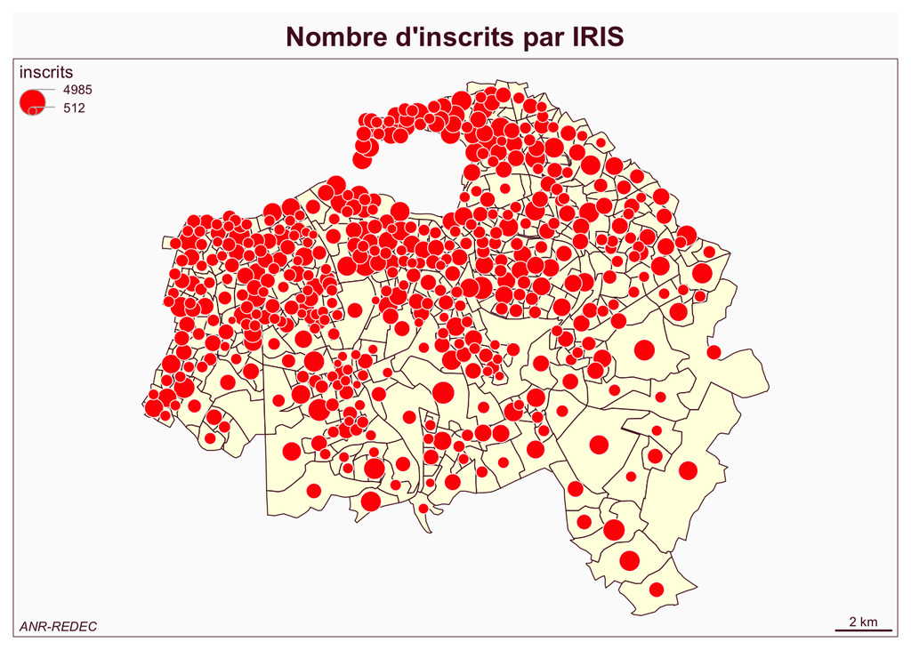

## Equalizing size by duplication of IRIS

We propose to transform the distribution of IRIS in order to obtain approximatively equal size units comprise between 250 and 750. For example an IRIS with a size of 800 will be transform in two IRIS of size 400. An IRIS of size 1800 in three IRISof sise 600, etc…

On obtient ainsi une distribution en unité de taille beaucoup plus voisines qu’avec les IRIS ce qui va permettre de simplifier les analyses ultérieures.

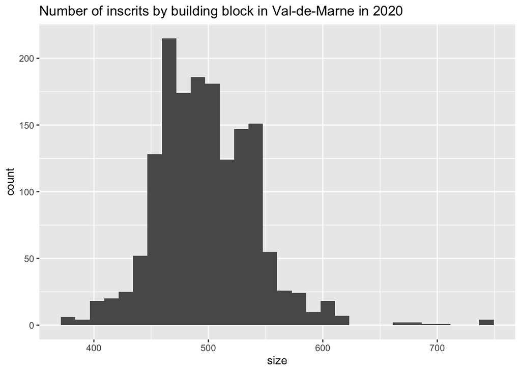

## Localization in euclidian space

The idea is to project or units with approximate equal size in an euclidean space in order to benefit from some interesting properties and to use existing algorithm of classification.

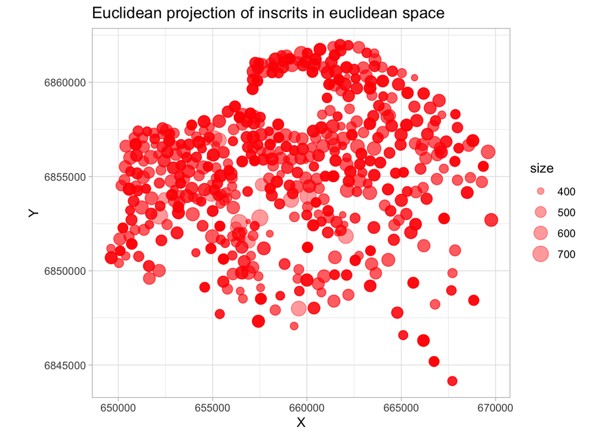

## K-means without constraint

It is now possible to use classification methods based on the euclidean distance like k-means without constraint and examine the results of clustering for 11 circonscriptions

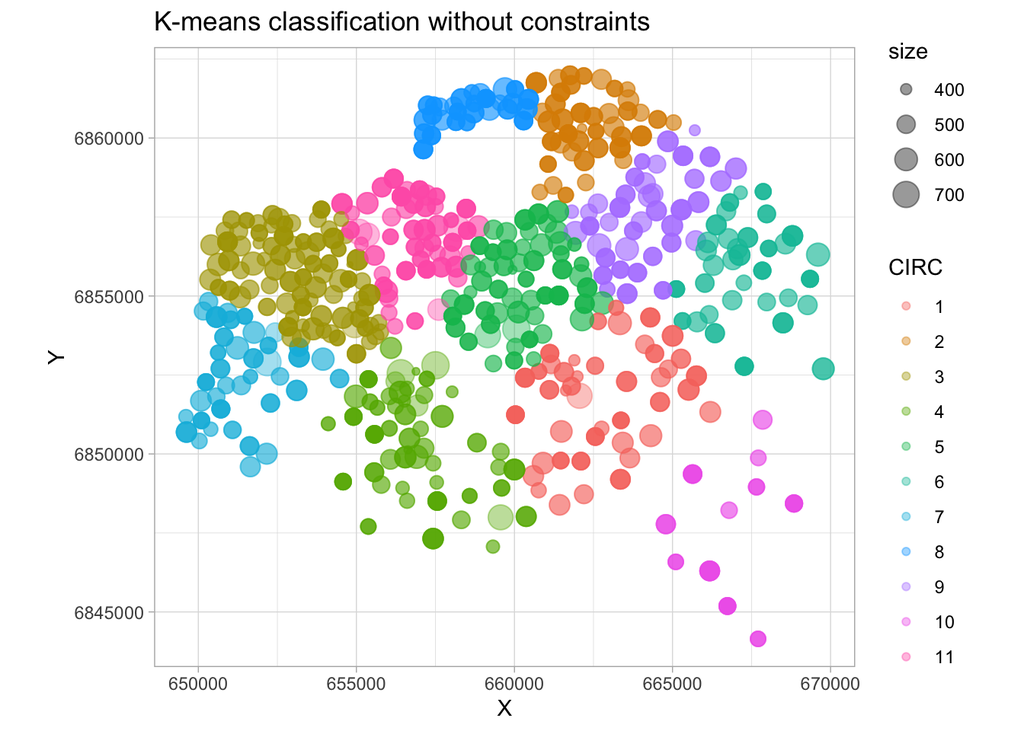

But the main issue with this first approach is the fact that the units does not fulffil the condition of equal number of building blocks and equal size in terms of inscrits.

| CIRC | nbunit | nbinscrits | index |
| --- | --- | --- | --- |
| 10 | 48 | 23074 | 32.2 |
| 8 | 114 | 57288 | 80.1 |
| 6 | 115 | 57684 | 80.6 |
| 7 | 124 | 61798 | 86.4 |
| 1 | 141 | 70381 | 98.4 |
| 9 | 139 | 70886 | 99.1 |
| 2 | 147 | 73351 | 102.5 |
| 4 | 151 | 73860 | 103.2 |
| 11 | 174 | 86734 | 121.2 |
| 5 | 177 | 88836 | 124.1 |
| 3 | 251 | 123254 | 172.2 |

## K-means with equal size constraint

Some authors has developped methods that take into account a constraint of equal size of cluster. As an example we have use the function *balanced_cluster()* of the package **anticluster** which make possible to obtain cluster with exacly the same number of individuals. Unfortunately the authors of the package has decided that “exactly means exactly” … which means that we are obliged to “cheat” our data if the number of units can not be divided by the number of expected cluster … In our example, we have 1581 units to be divided in 11 circonscription and the program does not work until we add 3 “pseudo units” in order to fulfill the condition $(1584/11 = 144)$.

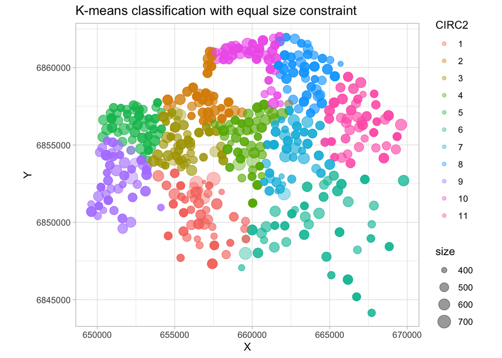

The number of units is no equal (except our 3 cheating units) and as a consequence, the circonscription of low density located in the SE of the Val-de-Marne become much larger, contrary to the circonscriptions located near Paris where the density ismuch higher. We can control that the result fit nicely withour expectations in terms of equal population.

| CIRC2 | nbunit | nbinscrits | index |
| --- | --- | --- | --- |
| 1 | 143 | 69793 | 97.5 |
| 5 | 144 | 70695 | 98.8 |
| 3 | 144 | 70881 | 99.1 |
| 7 | 143 | 70911 | 99.1 |
| 9 | 144 | 71318 | 99.7 |
| 8 | 144 | 72034 | 100.7 |
| 2 | 144 | 72193 | 100.9 |
| 6 | 144 | 72201 | 100.9 |
| 4 | 144 | 72248 | 101.0 |
| 10 | 144 | 72386 | 101.2 |
| 11 | 143 | 72486 | 101.3 |

## Difference between model and reality

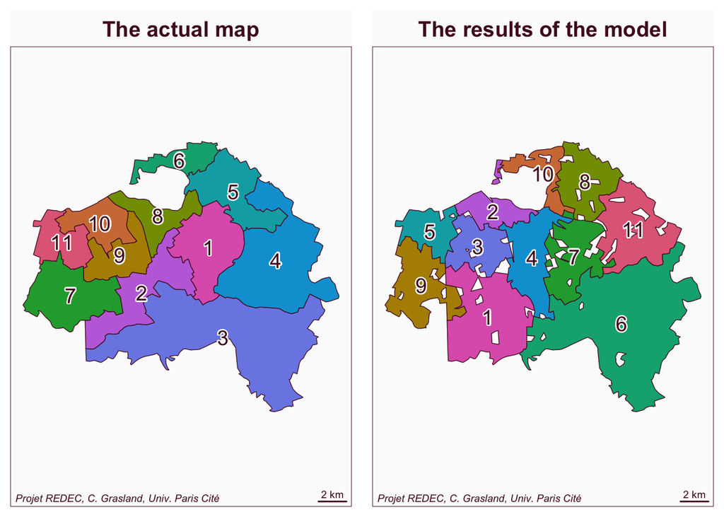

The holes in the model are related to the fact that some IRIS has not been classified because there was no population inside. But the figures are sufficient to observe similarities and differences between the reality and the model.